# Practical Machine Learning Assignment

Zhang Jiasheng

April 3, 2016

## Summary

One thing that people regularly do is quantify how much of a particular activity they do, but they rarely quantify how well they do it. The report will use data from accelerometers on the belt, forearm, arm, and dumbell of participants to predict the manner in which praticipants did the exercise.

### Read and Clean Data

```r
training<-read.csv("pml-training.csv", na.strings = c("NA",""),header =  T)
testing<-read.csv("pml-testing.csv",na.strings=c("NA",""),header = T)
dim(training);dim(testing)
```

```
## [1] 19622   160
```

```
## [1]  20 160
```

- Now, we remove the variables which have too many NA values.

```r
trainingData<-training[,colSums(is.na(training))==0]
```

- Next, we remove the irrelevant variables.

```r
remove=c('X','user_name','raw_timestamp_part_1','raw_timestamp_part_2','cvtd_timestamp','new_window','num_window')
trainingset<-trainingData[,-which(names(training) %in% remove)]
```

- Then, check variables have very low variance

```r
library(caret)
zeroVar<-nearZeroVar(trainingset[sapply(trainingset,is.numeric)],saveMetrics = TRUE)
training.nonzerovar=trainingset[,zeroVar[,'nzv']==0]
dim(training.nonzerovar)
```

```
## [1] 19622    53
```

- Last, the variables that are highly correlated will be excluded.

```r
corrMatrix<-cor(na.omit(training.nonzerovar[sapply(training.nonzerovar,is.numeric)]))
dim(corrMatrix)
```

```
## [1] 52 52
```

```r
remove_cor<-findCorrelation(corrMatrix,cutoff = .90,verbose = TRUE)
```

```
## Compare row 10  and column  1 with corr  0.992
##   Means:  0.27 vs 0.168 so flagging column 10
## Compare row 1  and column  9 with corr  0.925
##   Means:  0.25 vs 0.164 so flagging column 1
## Compare row 9  and column  4 with corr  0.928
##   Means:  0.233 vs 0.161 so flagging column 9
## Compare row 8  and column  2 with corr  0.966
##   Means:  0.245 vs 0.157 so flagging column 8
## Compare row 19  and column  18 with corr  0.918
##   Means:  0.091 vs 0.158 so flagging column 18
## Compare row 46  and column  31 with corr  0.914
##   Means:  0.101 vs 0.161 so flagging column 31
## Compare row 46  and column  33 with corr  0.933
##   Means:  0.083 vs 0.164 so flagging column 33
## All correlations <= 0.9
```

```r
training_finaldata<-training.nonzerovar[,-remove_cor]
dim(training_finaldata)
```

```
## [1] 19622    46
```

We are left with 19622 samples and 46 variables.

### Partition Data

```r
inTrain<-createDataPartition(y=training_finaldata$classe,p=0.7,list = FALSE)
trainset<-training_finaldata[inTrain,];testset<-training_finaldata[-inTrain,]
dim(trainset);dim(testset)
```

```
## [1] 13737    46
```

```
## [1] 5885   46
```

We got 13737 samples and 46 variables for training set, 5885 samples and 46 variables for testing set.

## Analysis

Fit a tree model to the training set.

```r
library(tree)
tree.training<-tree(classe~. ,data=trainset)
summary(tree.training)
```

```
##
## Classification tree:
## tree(formula = classe ~ ., data = trainset)
## Variables actually used in tree construction:
##  [1] "pitch_forearm"     "magnet_belt_y"     "accel_forearm_z"
##  [4] "magnet_dumbbell_y" "roll_forearm"      "magnet_dumbbell_z"
##  [7] "pitch_belt"        "yaw_belt"          "accel_dumbbell_y"
## [10] "yaw_forearm"       "magnet_forearm_z"  "accel_forearm_x"
## [13] "magnet_arm_x"      "accel_dumbbell_z"  "gyros_belt_z"
## Number of terminal nodes:  23
## Residual mean deviance:  1.54 = 21120 / 13710
## Misclassification error rate: 0.2859 = 3927 / 13737
```

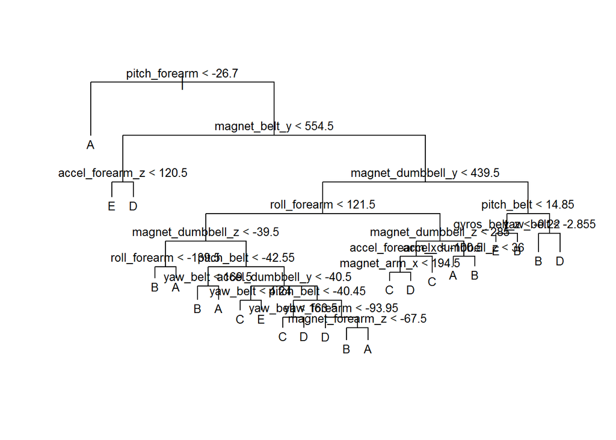

```r
plot(tree.training)
text(tree.training,pretty = 0,cex=0.8)
```

### Cross Validation

We are going to check the performance of the tree on the testing set by cross validation.

```r
tree.pred=predict(tree.training,testset,type="class")
predMatrix=with(testset,table(tree.pred,classe))
sum(diag(predMatrix))/sum(as.vector(predMatrix))
```

```
## [1] 0.7201359
```

It is around 0.7, which is not very accurate.

### Random Forests

To improve the accuracy , we use random forests method to build the model.

```r
require(randomForest)
```

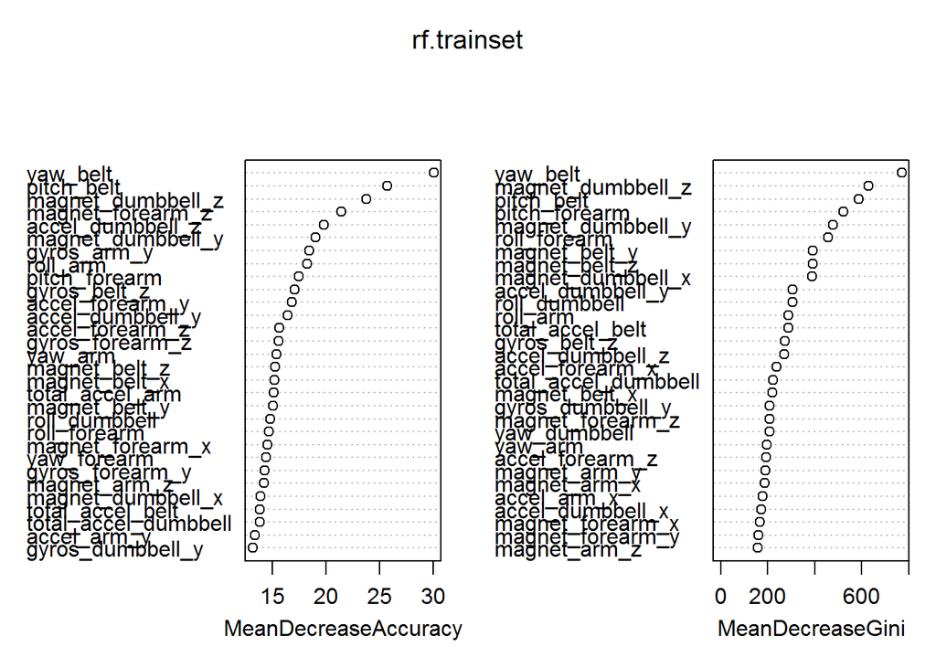

```r
rf.trainset=randomForest(classe~.,data=trainset,ntree=100,importance=TRUE)
varImpPlot(rf.trainset)
```

The plots above show which variables have higher impact on the prediction.

### Out-of-Sample Accuracy

Now we evaluate the prediction model on test set.

```r
tree.pred=predict(rf.trainset,testset,type="class")
predMatrix = with(testset,table(tree.pred,classe))
sum(diag(predMatrix))/sum(as.vector(predMatrix))
```

```
## [1] 0.9935429
```

The random forest model is very accurate. It gives us 0.99 accuracy.

## Conclusion

We then run our model against the testing dataset and display the predicted results.

```r
pred_final<-predict(rf.trainset,testing)
pred_final
```

```
##  1  2  3  4  5  6  7  8  9 10 11 12 13 14 15 16 17 18 19 20
##  B  A  B  A  A  E  D  B  A  A  B  C  B  A  E  E  A  B  B  B
## Levels: A B C D E
```